# Week 4: Lab - Map Data and Visualization–Tampa Crime

Jonathan Forte

2/4/2023

# Instructions

> **Warning: Do not copy and paste any code I give out here. You MUST write them up.** **If you copy and paste code from here to your RStudio, you will receive errors.**

In Chapter 13 we explored how to use “mashup” data to create a map and put additional data “on top of” the map. In this assignment, we will do that, but with one additional requirement to “zoom” into the region of the United States where the data is of interest.

First, read in the dataset `Police_calls_for_service.csv` (in the project’s data folder). The column show the description of crime, the address of the crime, Dispatched time, and the type of Report. As you can guess from the title of the data file, the focus of the dataset is crimes around the Tampa, FL area.

For this assignment, you need to create two different, but related, maps: A map with “points” for each of the crimes, and a “density map” showing the same information.

Install the “ggplot2” and “ggmap” packages as needed, and load the two packages in the setup code chunk below.

```r
# Add your library below.
library(ggplot2)
library(ggmap)
```

# Step 1 - A map with “points” for each of the crimes

## Step 1.1 - Read the data

1. Read in `Police_calls_for_service.csv` and save it as an object.
2. Investigate the data structure.

```r
# Write your code below.
crimeData <- read.csv("data/Police_calls_for_service.csv")
str(data)
```

```
## function (..., list = character(), package = NULL, lib.loc = NULL, verbose = getOption("verbose"),
##     envir = .GlobalEnv, overwrite = TRUE)
```

## Step 1.2 - Get your Google API Key

1. You need a Google API key for the next step, which uses the `geocode()` function. Google API requires you to register your credit card information.
   - To get the API key, follow the directions: https://developers.google.com/maps/documentation/geocoding/get-api-key
   - If you already have Google API key, go to https://console.cloud.google.com/google/maps-apis/api-list?project=uber-kmeans-1549390594743
     - Then click “Geocoding API” and enable it.
     - Go back a page, click “CREDENTIAL” in the left navigation bar
     - Retrieve your google API key.
     - Enter your API key in the `register_google()` function below.

```
## ℹ Replacing old key (REMOVED) with new key in C:/Users/andre/OneDrive/Documents/.Renviron
```

## Step 1.3 - Get Latitudes and Longitudes

1. Get latitudes and longitudes for all address in the crime dataset and store them in a new column using the `geocode()` function.
2. Make sure the new dataframe includes `lon` and `lat` columns.
3. Investigate the structure.

It should look something like this (details could be differ from your data):

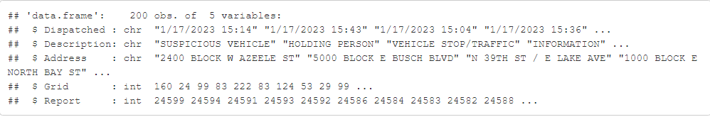

Step 1.3 Environment

```r
# Write your code below.
coordDF <- geocode(crimeData$Address)
```

```r
crimeData <- cbind(crimeData, coordDF)
str(data)
```

```
## function (..., list = character(), package = NULL, lib.loc = NULL, verbose = getOption("verbose"),
##     envir = .GlobalEnv, overwrite = TRUE)
```

## Step 1.4 - Create simpleMap object

Use the following code to create an object called `simpleMap`:

```
#get latitude and longtitude for USF
tampa <-geocode ("usf, tampa, fl")
tampa

# obtain maps from multiple sources and zoom into the region around tampaacuse university
tampa.map <-get_map(location=tampa, zoom=11)

# generate map and sore it in "simpleMap"
simpleMap <- ggmap(tampa.map)
# plot the map
simpleMap
```

```r
# Write your code below.
tampa <- geocode("usf, tampa, fl")
tampa
```

```
## # A tibble: 1 × 2
##     lon   lat
##   <dbl> <dbl>
## 1 -82.4  28.1
```

[figure not shown]

```r
tampa.map <- get_map(location = tampa, zoom = 11)
simpleMap <- ggmap(tampa.map)
simpleMap
```

## Step 1.5 - Create Tampa_crimemape

Create an object called `Tampa_crimemap` based on `simpleMap`, where each point represents one crime.

It should look like this:

[figure not shown]

Step 1.5 Map

[figure not shown]

```r
# Write your code below.
# crimeData$Description <- as.factor(crimeData$Description)
Tampa_crimemap <- simpleMap + geom_point(data = crimeData, aes(x = lon, y = lat, color = Description)) + guides(col = guide_legend(ncol = 2)) + theme(legend.key.size = unit(0.01, 'cm'))
Tampa_crimemap
```

# Step 2 - A “density map” showing the same information.

Use the `geom_density2d()` function. See the documentation as well as the ggplot cheatsheet to acquire more information on this.

The plot should look like this:

[figure not shown]

Step 2 Map

[figure not shown]

```r
# Write your code below.
simpleMap + geom_density2d(data = crimeData, aes(x = lon, y = lat))
```